# MonteCarlo 19

8 actividades, 6 rutas, distribución normal

# Enunciado

Considere el proyecto cuyo cuadro de prelaciones, duraciones medias y desviaciones típicas (en semanas) se adjunta. Suponga que la duración de cada actividad sigue una distribución normal.

1. Dibuje el grafo PERT, construya la matriz de caminos y calcule la duración del proyecto con las duraciones medias.

2. Genere 10000 réplicas de las duraciones de las actividades y, con la matriz de caminos, obtenga la duración del proyecto en cada una. Calcule su media, desviación típica y percentiles 5, 50 y 95.

3. Calcule la probabilidad de terminar en 32 semanas o menos y la duración que puede comprometerse con un 90% de probabilidad. Compare con la aproximación normal por el camino crítico y explique las diferencias.

4. Calcule el índice de criticidad de cada ruta y de cada actividad. ¿Qué actividad no crítica convendría vigilar?

Tabla 1: Cuadro de datos del enunciado

| activity | predecessor | duration | standard_deviation |
| --- | --- | --- | --- |
| A | --- | 8 | 0.8 |
| B | --- | 6 | 0.6 |
| C | --- | 8 | 0.6 |
| D | A,B | 6 | 0.4 |
| E | B,C | 8 | 1.0 |
| F | C,D | 3 | 0.8 |
| G | E,F | 6 | 0.6 |
| H | G | 8 | 0.6 |

# Resolución

## Apartado 1

1. Dibuje el grafo PERT, construya la matriz de caminos y calcule la duración del proyecto con las duraciones medias.

Cálculo de los tiempos tempranos y tardíos de los sucesos y de las holguras totales paso a paso. El primer paso muestra el grafo resuelto; a partir del siguiente se calcula desde el principio (avance con los botones):

[figure not shown]

paso 0 de 29

[figure not shown]

Figura 1: Grafo PERT con las duraciones medias

La matriz de caminos tiene una fila por ruta y una columna por actividad (1 si la actividad está en la ruta):

Tabla 2: Matriz de caminos

[figure not shown]

ninguna ruta (0 de 6)

[figure not shown]

👆 **Interactivo:** haz clic en una fila de la matriz para resaltar en el grafo las actividades y los nodos de esa ruta (otro clic la deselecciona), o usa los botones y las flechas del teclado.

Duración media y varianza de cada ruta (producto de la matriz de caminos por las medias y por las varianzas de las actividades):

|  | actividades | media = suma | media | varianza = suma | varianza | σ = √varianza |
| --- | --- | --- | --- | --- | --- | --- |
| Route_1 | A – D – F – G – H | A(8) + D(6) + F(3) + G(6) + H(8) = 31 | 31 | A(0.640) + D(0.160) + F(0.640) + G(0.360) + H(0.360) = 2.160 | 2.160 | 1.470 |
| Route_2 | B – D – F – G – H | B(6) + D(6) + F(3) + G(6) + H(8) = 29 | 29 | B(0.360) + D(0.160) + F(0.640) + G(0.360) + H(0.360) = 1.880 | 1.880 | 1.371 |
| Route_3 | B – E – G – H | B(6) + E(8) + G(6) + H(8) = 28 | 28 | B(0.360) + E(1.000) + G(0.360) + H(0.360) = 2.080 | 2.080 | 1.442 |
| Route_4 | B – F – G – H | B(6) + F(3) + G(6) + H(8) = 23 | 23 | B(0.360) + F(0.640) + G(0.360) + H(0.360) = 1.720 | 1.720 | 1.311 |
| Route_5 | C – E – G – H | C(8) + E(8) + G(6) + H(8) = 30 | 30 | C(0.360) + E(1.000) + G(0.360) + H(0.360) = 2.080 | 2.080 | 1.442 |
| Route_6 | C – F – G – H | C(8) + F(3) + G(6) + H(8) = 25 | 25 | C(0.360) + F(0.640) + G(0.360) + H(0.360) = 1.720 | 1.720 | 1.311 |

σ_T = √(0.640 + 0.160 + 0.640 + 0.360 + 0.360) = √2.160 = **1.470**.

**Respuesta:** con las duraciones medias el proyecto dura 31 semanas; la ruta crítica es A – D – F – G – H, con desviación típica σ_T = 1.470 semanas.

## Apartado 2

2. Genere 10000 réplicas de las duraciones de las actividades y, con la matriz de caminos, obtenga la duración del proyecto en cada una. Calcule su media, desviación típica y percentiles 5, 50 y 95.

Cada réplica es un vector de duraciones, una por actividad, generado con su distribución normal (truncada en cero por seguridad).

Comprobación de que las muestras reproducen la media y la dispersión de cada actividad:

Tabla 3: Medias y desviaciones típicas muestrales frente a las teóricas

|  | A | B | C | D | E | F | G | H |
| --- | --- | --- | --- | --- | --- | --- | --- | --- |
| media teórica | 8.00 | 6.0 | 8.0 | 6.0 | 8.00 | 3.00 | 6.0 | 8.00 |
| media muestral | 7.99 | 6.0 | 8.0 | 6.0 | 8.01 | 2.99 | 6.0 | 7.99 |
| σ teórica | 0.80 | 0.6 | 0.6 | 0.4 | 1.00 | 0.80 | 0.6 | 0.60 |
| σ muestral | 0.80 | 0.6 | 0.6 | 0.4 | 1.00 | 0.81 | 0.6 | 0.60 |

La duración de cada ruta en cada réplica es la suma de las duraciones de sus actividades (producto de las duraciones por la traspuesta de la matriz de caminos), y la del proyecto es la de la ruta más larga: el máximo por filas. Las cinco primeras réplicas:

|  | Route_1 | Route_2 | Route_3 | Route_4 | Route_5 | Route_6 | Proyecto (máximo) |
| --- | --- | --- | --- | --- | --- | --- | --- |
| 0 | 30.62 | 28.74 | 26.87 | 22.51 | 28.14 | 23.78 | 30.62 |
| 1 | 30.68 | 27.82 | 27.07 | 21.66 | 28.94 | 23.52 | 30.68 |
| 2 | 32.08 | 31.62 | 27.98 | 25.03 | 28.90 | 25.95 | 32.08 |
| 3 | 31.44 | 29.31 | 28.51 | 23.78 | 29.86 | 25.13 | 31.44 |
| 4 | 32.89 | 28.93 | 28.62 | 22.98 | 30.80 | 25.17 | 32.89 |

Los descriptores se calculan sobre las réplicas de la duración del proyecto. El percentil $p$ es el valor que deja por debajo la proporción $p$ de las réplicas: se ordenan de menor a mayor y se toma la que ocupa la posición $p\cdot N$ (interpolando entre las dos vecinas).

Tabla 4: Descriptores de la duración simulada del proyecto

|  | réplicas | media | desviación típica | mínimo | P5 | P50 | P95 | máximo |
| --- | --- | --- | --- | --- | --- | --- | --- | --- |
| Duración del proyecto (semanas) | 10000.0 | 31.27 | 1.33 | 26.84 | 29.13 | 31.26 | 33.47 | 36.46 |

Por ejemplo, el P95 está entre la réplica 9500 y la 9501 de las 10000 ordenadas (33.47 y 33.47).

**Respuesta:** media 31.27 semanas, desviación típica 1.33; percentiles P5 = 29.13, P50 = 31.26 y P95 = 33.47 semanas.

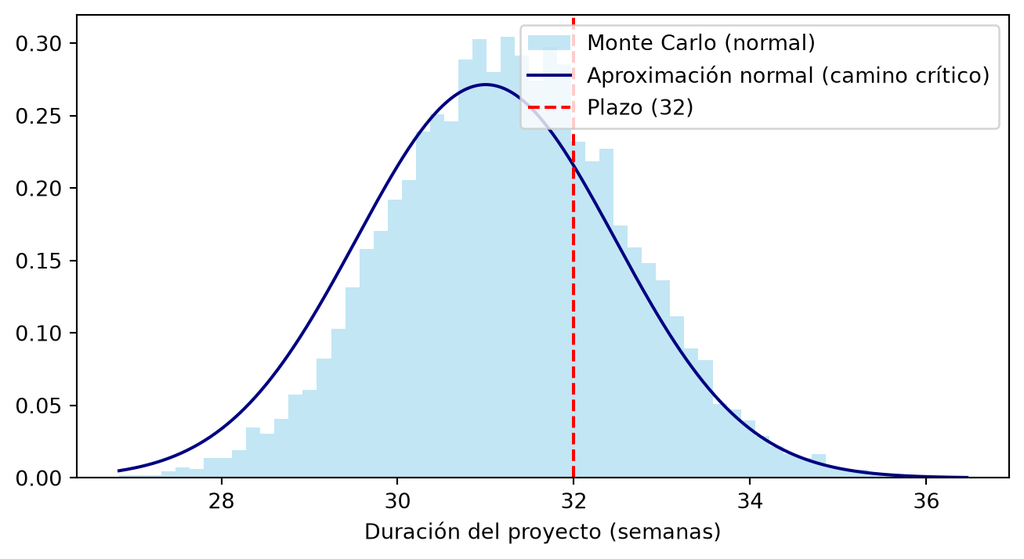

Figura 2: Distribución simulada de la duración frente a la aproximación normal

## Apartado 3

3. Calcule la probabilidad de terminar en 32 semanas o menos y la duración que puede comprometerse con un 90% de probabilidad. Compare con la aproximación normal por el camino crítico y explique las diferencias.

Con las réplicas, la probabilidad de cumplir el plazo es la proporción de réplicas que no lo superan, y la duración que se cumple con una probabilidad dada es el percentil empírico correspondiente. Con la aproximación normal, $T \sim N(\mu, \sigma_T)$ con la media y la desviación típica de la ruta crítica (apartado 1).

Monte Carlo: 7129 de las 10000 réplicas duran 32 semanas o menos, luego P(T ≤ 32) ≈ 7129/10000 = **0.7129**; el percentil 90 de las réplicas (posición ≈ 9000 de 10000 ordenadas) es **32.99** semanas.

Aproximación normal:

- P(T ≤ 32), con T ~ N(μ = 31; σ = 1.470): `=DISTR.NORM.N(32; 31; 1,4697; VERDADERO)` = **0.7519** (75.2%)

- t tal que P(T ≤ t) = 0.9, con T ~ N(μ = 31; σ = 1.470): `=INV.NORM(0,9; 31; 1,4697)` = **32.88** semanas

Tabla 5: Aproximación normal frente a Monte Carlo

|  | Aproximación normal | Monte Carlo |
| --- | --- | --- |
| Duración media | 31.00 | 31.27 |
| Desviación típica | 1.47 | 1.33 |
| P(T ≤ 32) (%) | 75.19 | 71.29 |
| Duración para 90% | 32.88 | 32.99 |

Monte Carlo da una duración media 0.27 semanas mayor. En cada réplica la duración del proyecto es el máximo de todas las rutas y en el 29.0 % de las réplicas manda otra ruta distinta de la crítica: las rutas casi críticas empujan la duración hacia arriba (*sesgo de fusión*), algo que la aproximación normal, que sólo mira la ruta crítica, no recoge. La probabilidad de cumplir el plazo es menor con Monte Carlo (0.7129 frente a 0.7519) y la duración al 90 % mayor (32.99 frente a 32.88): la aproximación normal por el camino crítico es optimista. La desviación típica simulada es menor (1.33 frente a 1.47): cuando la ruta crítica sale corta otra ocupa su lugar y la cola izquierda se recorta.

**Respuesta:** P(T ≤ 32) ≈ 0.7129 con Monte Carlo y 0.7519 con la aproximación normal; la duración que se cumple con un 90 % de probabilidad es 32.99 semanas con Monte Carlo y 32.88 con la normal (en semanas enteras, 33 y 33).

## Apartado 4

4. Calcule el índice de criticidad de cada ruta y de cada actividad. ¿Qué actividad no crítica convendría vigilar?

El índice de criticidad de una ruta es la fracción de réplicas en que es la más larga; el de una actividad, la fracción de réplicas en que pertenece a la ruta más larga.

Tabla 6: Índice de criticidad de las rutas

|  | actividades | duración media | veces la más larga | criticidad (%) |
| --- | --- | --- | --- | --- |
| Route_1 | A – D – F – G – H | 31 | 7104 | 71.0 |
| Route_5 | C – E – G – H | 30 | 2780 | 27.8 |
| Route_2 | B – D – F – G – H | 29 | 98 | 1.0 |
| Route_3 | B – E – G – H | 28 | 18 | 0.2 |
| Route_4 | B – F – G – H | 23 | 0 | 0.0 |
| Route_6 | C – F – G – H | 25 | 0 | 0.0 |

Tabla 7: Índice de criticidad de las actividades frente a su holgura total

|  | A | B | C | D | E | F | G | H |
| --- | --- | --- | --- | --- | --- | --- | --- | --- |
| holgura total | 0.0 | 2.0 | 1.0 | 0.0 | 1.0 | 0.0 | 0.0 | 0.0 |
| criticidad (%) | 71.0 | 1.2 | 27.8 | 72.0 | 28.0 | 72.0 | 100.0 | 100.0 |

La librería hace el mismo cálculo de forma vectorizada: la sensibilidad empírica media de `monte_carlo` es precisamente el índice de criticidad de cada actividad.

|  | media | desv. típica | P5 | P50 | P95 | mínimo | máximo |
| --- | --- | --- | --- | --- | --- | --- | --- |
| τ | 31.27 | 1.33 | 29.13 | 31.26 | 33.47 | 26.84 | 36.46 |

|  | G | H | D | F | A | E | C | B |
| --- | --- | --- | --- | --- | --- | --- | --- | --- |
| criticidad (%) según monte_carlo | 100.0 | 100.0 | 72.0 | 72.0 | 71.0 | 28.0 | 27.8 | 1.2 |

**Respuesta:** índices de criticidad de las rutas (las que alguna vez son la más larga): A – D – F – G – H: 71.0 %; C – E – G – H: 27.8 %; B – D – F – G – H: 1.0 %; B – E – G – H: 0.2 %. Los de las actividades son los de la tabla. La actividad no crítica que convendría vigilar es **E**: está en la ruta más larga en el 28.0 % de las réplicas aunque tiene 1 semana de holgura total. El análisis determinista la da por holgada, pero un retraso pequeño la convierte en crítica.